# Unsupervised learning

Most of the course covered supervised learning methods such as regression and classification. In the supervised learning setting, we typically have access to a set of $p$ features $X_1, X_2, \ldots, X_p$, measured on $n$ observations, and a response $Y$ also measured on those same $n$ observations. The goal is then to predict $Y$ using $X_1, X_2, \ldots, X_p$.

Now we will instead focus on *unsupervised learning*, a set of statistical tools intended for the setting in which we have only a set of features $X_1, X_2, \ldots, X_p$ measured on $n$ observations and we do not have an associated response variable $Y$.

Rather, the goal is to discover interesting things about the measurements on $X_1, X_2, \ldots, X_p$.

Is there an informative way to visualize the data? Can we discover subgroups among the variables or among the observations?

**Main problem:** there is no way to check our work because we don’t know the true answer.

## Principal component analysis

PCA is an unsupervised approach, since it involves only a set of features $X_1, X_2, \ldots, X_p$, and no associated response $Y$. Apart from producing derived variables for use in supervised learning problems, PCA also serves as a tool for data visualization.

Suppose that we wish to visualize $n$ observations with measurements on a set of $p$ features as part of an exploratory data analysis. We could do this by examining two-dimensional scatterplots of the data.

However, if $p$ is large, then it will certainly not be possible to look at all of them; moreover, most likely none of them will be informative since they each contain just a small fraction of the total information present in the data set.

We would like to find a low-dimensional representation of the data that captures as much of the information as possible.

The idea of *PCA* is that each of the $n$ observations lives in $p$-dimensional space, but not all of these dimensions are equally interesting.

The first principal component loading vector $\boldsymbol{\phi}_1 = (\phi_{11}, \phi_{21}, \ldots, \phi_{p1})^\top$ solves the optimization problem

$$\text{maximize}_{\phi_{11}, \phi_{21}, \ldots, \phi_{p1}} \left\{\frac{1}{n}\sum_{i=1}^n\left(\sum_{j=1}^p \phi_{j1}x_{ij}\right)^2\right\} \text{ subject to} \sum_{j=1}^p \phi_{j1}^2 = 1.$$

We refer to $z_{i1} = \phi_{11}x_{i1} + \ldots + \phi_{p1} x_{ip}$ as the score of the first principal component.

After the first principal component $Z_1$ of the features has been determined, we can find the second principal component $Z_2$. The second principal component is the linear combination of $X_1, \ldots, X_p$ that has maximal variance out of all linear combinations that are uncorrelated with $Z_1$ ($\boldsymbol{\phi}_2$ should be orthogonal to $\boldsymbol{\phi}_1$).

Once we have computed the principal components, we can plot them against each other in order to produce low-dimensional views of the data. For instance, we can plot the score vector $Z_1$ against $Z_2$, $Z_1$ against $Z_3$, $Z_2$ against $Z_3$, and so forth. Geometrically, this amounts to projecting the original data down onto the subspace spanned by $\boldsymbol{\phi}_1$, $\boldsymbol{\phi}_2$, and $\boldsymbol{\phi}_3$, and plotting the projected points.

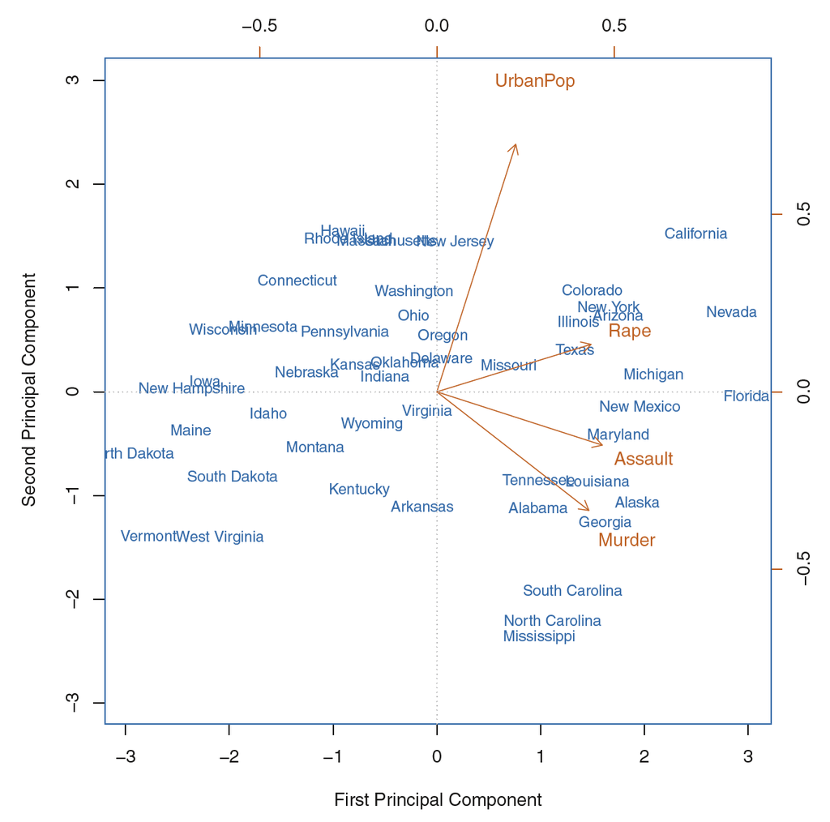

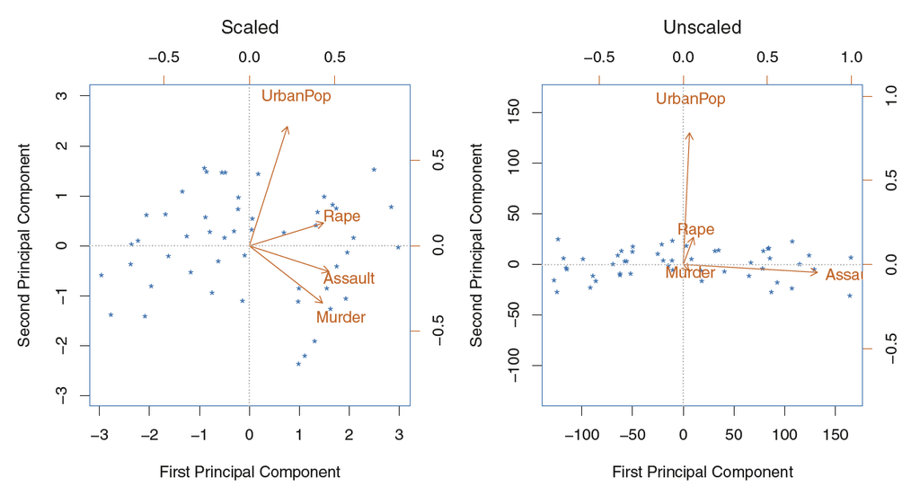

In certain settings, however, the variables may be measured in the same units. In this case, we might not wish to scale the variables to have standard deviation one before performing PCA. For instance, suppose that the variables in a given data set correspond to expression levels for $p$ genes. Then since expression is measured in the same “units” for each gene, we might choose not to scale the genes to each have standard deviation one.

**Note:** each principal component loading vector is unique, up to a sign flip. There can be $\min(n-1, p)$ princiapl components in total.

### How much of the information is lost by projecting the observations onto the first few principal components?

The total variance present in a data set is defined as

$$\sum_{j=1}^p \text{Var}(X_j) = \sum_{j=1}^p\frac{1}{n}\sum_{i=1}^n x_{ij}^2,$$

and the variance explained by the $m$th principal component is

$$\frac{1}{n}\sum_{i=1}^n z_{im}^2 = \frac{1}{n}\sum_{i=1}^n \left(\sum_{j=1}^p \phi_{jm}x_{ij}\right)^2.$$

Therefore, the *proportion of variance explained* (PVE) of the $m$th principal component is given by

$$\frac{\sum_{i=1}^n \left(\sum_{j=1}^p \phi_{jm}x_{ij}\right)^2}{\sum_{j=1}^p\sum_{i=1}^n x_{ij}^2}.$$

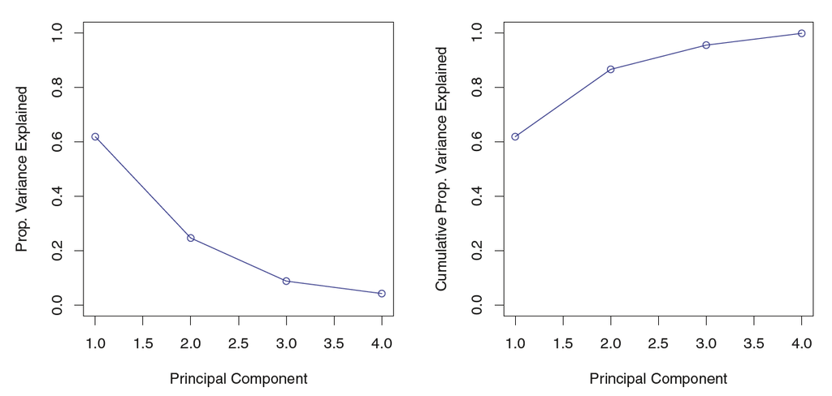

### How many PCs to use?

We typically decide on the number of principal components required to visualize the data by examining a scree plot. We choose the smallest number of principal components that are required in order to explain a sizable amount of the variation in the data. This is done by eyeballing the scree plot, and looking for a point at which the proportion of variance explained by each subsequent principal component drops off. This is often referred to as an elbow in the scree plot.

Unfortunately, there is no well-accepted objective way to decide how many principal components are enough.

In practice, we tend to look at the first few principal components in order to find interesting patterns in the data. If no interesting patterns are found in the first few principal components, then further principal components are unlikely to be of interest. Conversely, if the first few principal components are interesting, then we typically continue to look at subsequent principal components until no further interesting patterns are found.

This is reflective of the fact that PCA is generally used as a tool for exploratory data analysis.

## Clustering

Clustering refers to a very broad set of techniques for finding subgroups, or clusters, in a data set.

When we cluster the observations of a data set, we seek to partition them into distinct groups so that the observations within each group are quite similar to each other, while observations in different groups are quite different from each other.

### $K$-means clustering

$K$-means clustering is a simple and elegant approach for partitioning a data set into $K$ distinct, non-overlapping clusters.

To perform $K$-means clustering, we must first specify the desired number of clusters $K$; then the $K$-means algorithm will assign each observation to exactly one of the $K$ clusters.

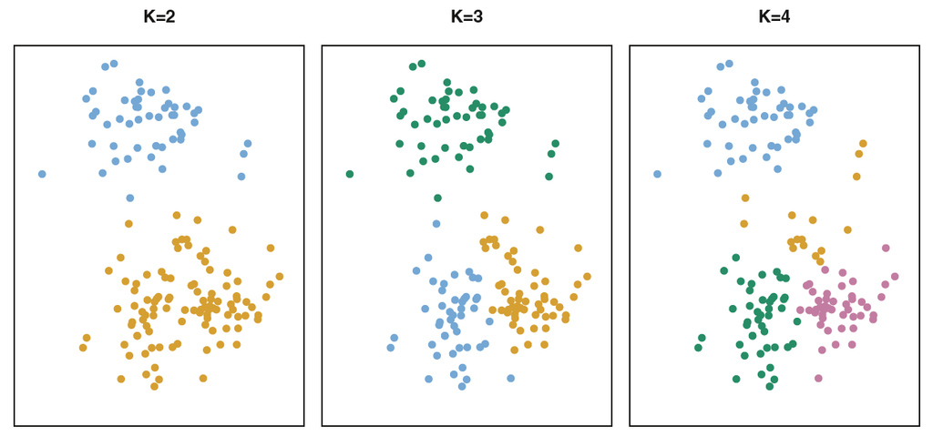

Let $C_1, \ldots, C_K$ denote sets containing the indices of the observations in each cluster. These sets satisfy two properties:

1. $C_1 \cup C_2 \cup \ldots \cup C_K = \{1, \ldots, n\}$.
2. $C_k \cap C_{k^\prime} = \emptyset$ for all $k  \neq k^\prime$.

The idea behind $K$-means clustering is that a good clustering is one for which the *within-cluster variation* is as small as possible. The within-cluster variation for cluster $C_k$ is a measure $W(C_k)$ of the amount by which the observations within a cluster differ from each other. We want to partition the observations into $K$ clusters such that the total within-cluster variation, summed over all $K$ clusters, is as small as possible:

$$\text{minimize}_{C_{1}, C_{2}, \ldots, C_{K}} \left\{\sum_{k=1}^K W(C_k)\right\}.$$

The most common choice of the within cluster variation involves squared Euclidean distance:

$$W(C_k) = \frac{1}{|C_k|}\sum_{i, i^\prime \in C_k}\sum_{j=1}^p\left(x_{ij} - x_{i^\prime j}\right)^2.$$

**Algorithm of $K$-means clustering:**

1. Randomly assign a number, from $1$ to $K$, to each of the observations. These serve as initial cluster assignments for the observations.
2. Iterate until the cluster assignments stop changing:\ a) For each of the $K$ clusters, compute the cluster centroid. The $k$th cluster centroid is the vector of the $p$ feature means for the observations in the $k$th cluster.\ b) Assign each observation to the cluster whose centroid is closest (where closest is defined using Euclidean distance).

This algorithm is guaranteed to decrease the value of the objective at each step. To understand why, note the following:

$$\frac{1}{|C_k|}\sum_{i, i^\prime \in C_k}\sum_{j=1}^p\left(x_{ij} - x_{i^\prime j}\right)^2 = 2\sum_{i \in C_k}\sum_{j=1}^p\left(x_{ij} - \bar{x}_{k j}\right)^2,$$

where $\bar{x}_{k j} = \frac{1}{|C_k|}\sum_{i \in C_k}x_{ij}$ is the mean for feature $j$ in cluster $C_k$.

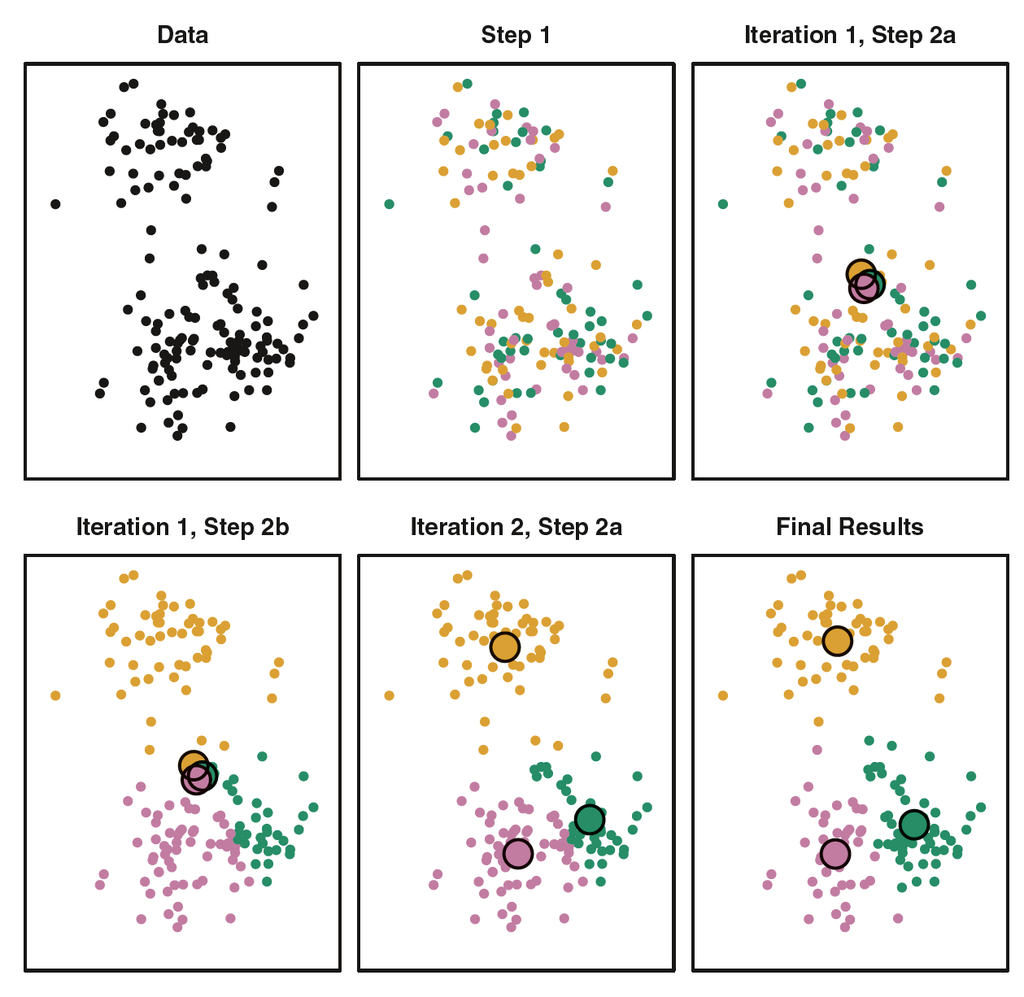

Because the $K$-means algorithm finds a local rather than a global optimum, the results obtained will depend on the initial (random) cluster assignment of each observation in Step 1 of the algorithm. For this reason, it is important to run the algorithm multiple times from different random initial configurations. Then one selects the best solution (where the objective is the smallest).

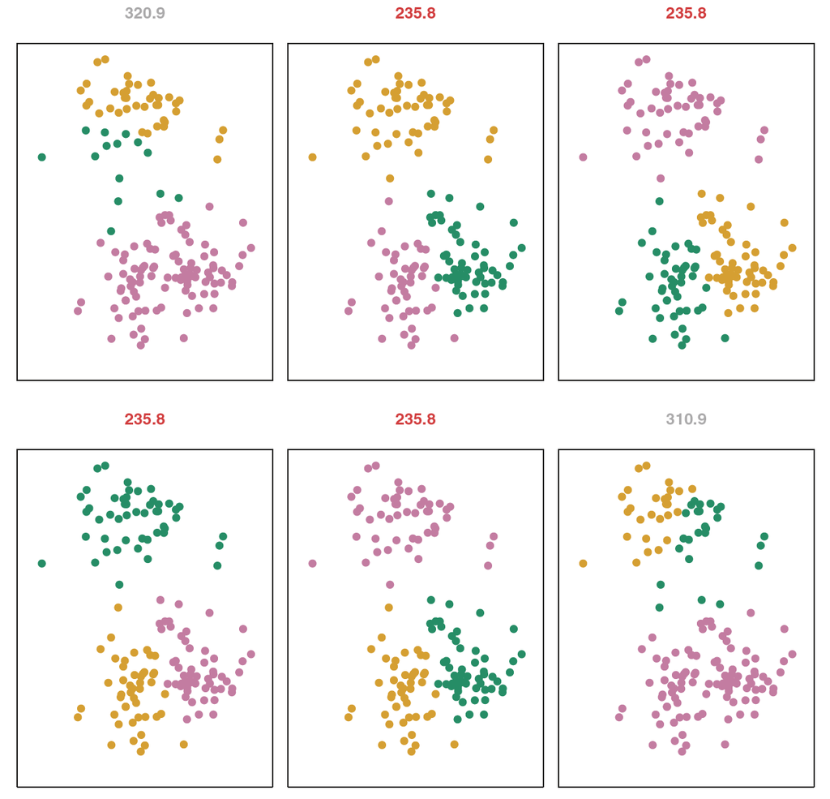

### Hierarchical clustering

Hierarchical clustering is an alternative approach which does not require that we commit to a particular choice of $K$. Hierarchical clustering has an added advantage over $K$-means clustering in that it results in an attractive tree-based representation of the observations, called a *dendrogram*.

Here, we describe *bottom-up* or *agglomerative* clustering. This is the most common type of hierarchical clustering, and refers to the fact that a dendrogram is built starting from the leaves and combining clusters up to the trunk.

**Important feature:** one single dendrogram can be used to obtain any number of clusters!

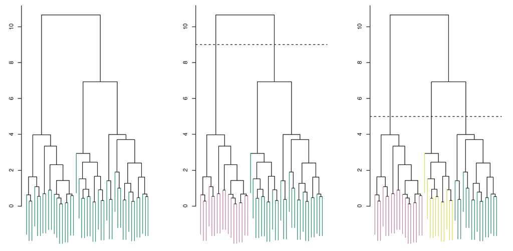

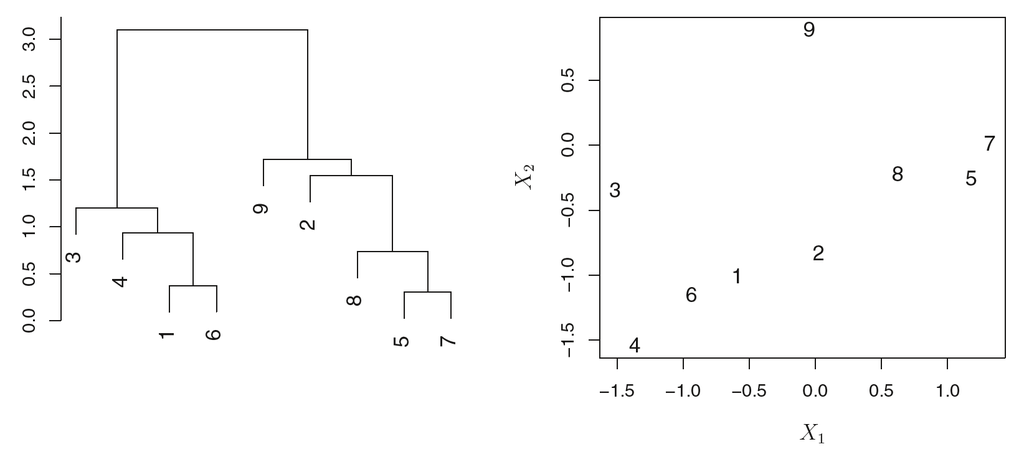

The term hierarchical refers to the fact that clusters obtained by cutting the dendrogram at a given height are necessarily nested within the clusters obtained by cutting the dendrogram at any greater height. However, on an arbitrary data set, this assumption of hierarchical structure might be unrealistic.

For instance, suppose that our observations correspond to a group of people with a 50–50 split of males and females, evenly split among Americans, Japanese, and French. We can imagine a scenario in which the best division into two groups might split these people by gender, and the best division into three groups might split them by nationality. In this case, the true clusters are not nested, in the sense that the best division into three groups does not result from taking the best division into two groups and splitting up one of those groups. Consequently, this situation could not be well-represented by hierarchical clustering.

Due to situations such as this one, hierarchical clustering can sometimes yield worse (i.e. less accurate) results than $K$-means clustering for a given number of clusters.

**Algorithm of the Hierarchical Clustering:**

1. Begin with $n$ observations and a measure (such as Euclidean distance) of all the $n(n−1)/2$ pairwise dissimilarities. Treat each observation as its own cluster.
2. For $i = n, n − 1, \ldots, 2$:\ a) Examine all pairwise inter-cluster dissimilarities among the $i$ clusters and identify the pair of clusters that are least dissimilar. Fuse these two clusters. The dissimilarity between these two clusters indicates the height in the dendrogram at which the fusion should be placed.\ b) Compute the new pairwise inter-cluster dissimilarities among the $i − 1$ remaining clusters.

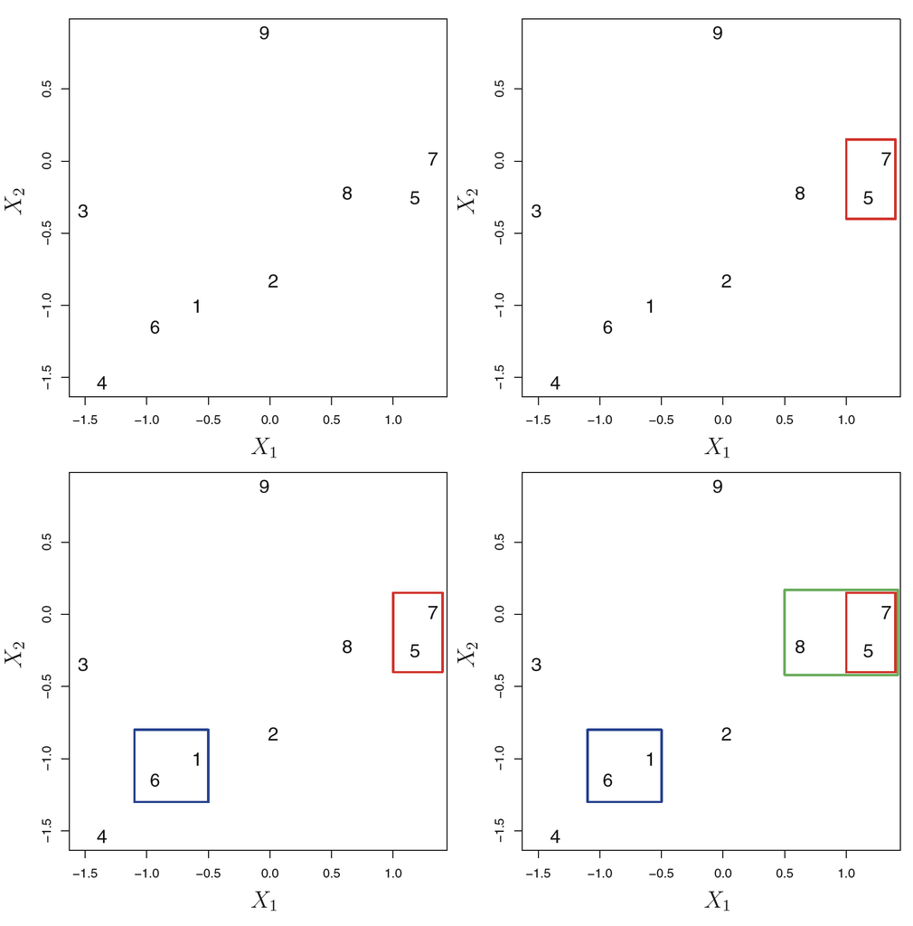

The concept of dissimilarity between a pair of observations needs to be extended to a pair of groups of observations. This extension is achieved by developing the notion of linkage, which defines the dissimilarity between two groups of observations. The four most common types of linkage are the following:

1. Complete: Maximal intercluster dissimilarity. Compute all pairwise dissimilarities between the observations in cluster A and the observations in cluster B, and record the largest of these dissimilarities.
2. Single: Minimal intercluster dissimilarity. Compute all pairwise dissimilarities between the observations in cluster A and the observations in cluster B, and record the smallest of these dissimilarities. Single linkage can result in extended, trailing clusters in which single observations are fused one-at-a-time.
3. Average: Mean intercluster dissimilarity. Compute all pairwise dissimilarities between the observations in cluster A and the observations in cluster B, and record the average of these dissimilarities.
4. Centroid: Dissimilarity between the centroid for cluster A (a mean vector of length $p$) and the centroid for cluster B.

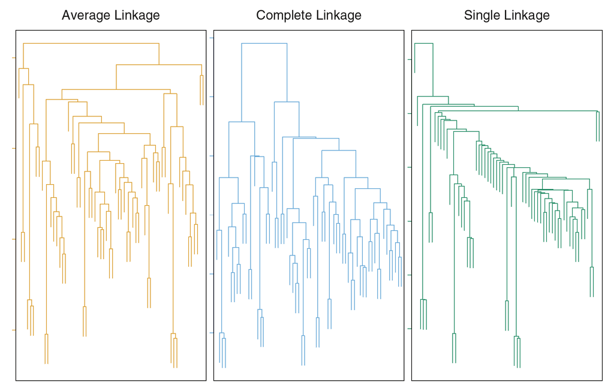

### Practical issues

1. Should the observations or features first be standardized in some way? For instance, maybe the variables should be centered to have mean zero and scaled to have standard deviation one.
2. In the case of hierarchical clustering,\ – What dissimilarity measure should be used?\ – What type of linkage should be used?\ – Where should we cut the dendrogram in order to obtain clusters?
3. In the case of $K$-means clustering, how many clusters should we look for in the data?